# First_Lab

Московский государственный технический университет им. Н.Э. Баумана  
Факультет «Информатика и системы управления»  
Кафедра «Автоматизированные системы обработки информации и управления»

[figure not shown]

Отчет по лабораторной работе № 1  
"Разведочный анализ данных. Исследование и визуализация данных."  
По курсу  
“Методы машинного обучения”

Выполнила:  
Шаххуд Ф.М.  
Студентка группы ИУ5-12М

Москва, 2020

## Цель лабораторной работы

изучая различные графики данных и пытаясь выяснить связь между некоторыми переменными в нашем наборе данных, используя такие библиотеки, как matplotlib и seaborn.

## описание набора данных

В качестве набора данных мы будем использовать набор данных, представленный scikit-learn.org, который демонстрирует стоимость дома в Бостоне. Копия базы данных: https://archive.ics.uci.edu/ml/machine-learning-databases/housing/

Этот набор данных имеет характеристики дома и его цену, поэтому прогнозирующая модель может прогнозировать цену дома в районе Бостона на основе его характеристик.

Атрибуты, которые описывают дом и включены в набор данных как колонок:

- CRIM: уровень преступности на душу населения по городам.
- ZN: доля жилой земли, зонированной для участков более 25 000 кв. Футов.
- INDUS: доля не-розничных бизнес-акров на город.
- CHAS: Фиктивная переменная реки Чарльз (= 1, если тракт ограничивает реку; 0 в противном случае).
- NOX: концентрация оксидов азота (частей на 10 миллионов).
- RM: среднее количество комнат на одно жилище.
- AGE: доля домовладельцев, построенных до 1940 года.
- DIS: взвешивает расстояния до пяти бостонских центров занятости.
- RAD: индекс доступности к радиальным магистралям.
- TAX: ставка налога на полную стоимость имущества за 10 000 долл.
- PTRATIO: Соотношение учеников и учителей по городам.
- B: 1000 (Bk - 0,63)^2, где Bk - доля чернокожих по городам.
- LSTAT: % ниже статуса населения.
- MEDV: Медианная стоимость домов, занимаемых владельцами, в 1000 долл.

и целевые данные - цена дома, оцененная в [1k долл.]

## Импорт библиотек

```python
import pandas as pd
import numpy as np
import matplotlib.pyplot as plt
import seaborn as sns
import math
```

## Загрузка данных

мы собираемся загрузить набор данных о ценах на жилье в Бостоне из наборов данных пакета scikit learn, который содержит функцию прямой загрузки этого набора данных без внешних файлов.

```python
from sklearn.datasets import load_boston
boston=load_boston()
```

## Основные характеристики датасета

```python
#форма нашего набора данных
boston.data.shape
```

```
(506, 13)
```

Итак, мы видим, что наш набор данных имеет 506 строк данных и 13 объектов или переменных. чтобы увидеть, что находится внутри набора данных:

```python
for x in boston:
    print(x)
```

```
data
target
feature_names
DESCR
filename
```

Итак, мы видим, что имеем:

1. данные характеристик дома
2. цель, которая является ценой дома
3. Названия элементов, которые являются названиями атрибутов дома.
4. DESCR: описание всего набора данных.
5. имя файла нашего набора данных.

```python
#имена элементов столбцов в наборе данных
boston['feature_names']
```

```
array(['CRIM', 'ZN', 'INDUS', 'CHAS', 'NOX', 'RM', 'AGE', 'DIS', 'RAD',
       'TAX', 'PTRATIO', 'B', 'LSTAT'], dtype='<U7')
```

```python
#форма целевого столбца
boston['target'].shape
```

```
(506,)
```

Таким образом, форма цели соответствует форме нашего набора данных. Чтобы увидеть описание, предоставленное для набора данных, мы можем отобразить DESCR, который восстановлен внутри набора данных:

```python
print(boston['DESCR'])
```

```
.. _boston_dataset:

Boston house prices dataset
---------------------------

**Data Set Characteristics:**

    :Number of Instances: 506

    :Number of Attributes: 13 numeric/categorical predictive. Median Value (attribute 14) is usually the target.

    :Attribute Information (in order):
        - CRIM     per capita crime rate by town
        - ZN       proportion of residential land zoned for lots over 25,000 sq.ft.
        - INDUS    proportion of non-retail business acres per town
        - CHAS     Charles River dummy variable (= 1 if tract bounds river; 0 otherwise)
        - NOX      nitric oxides concentration (parts per 10 million)
        - RM       average number of rooms per dwelling
        - AGE      proportion of owner-occupied units built prior to 1940
        - DIS      weighted distances to five Boston employment centres
        - RAD      index of accessibility to radial highways
        - TAX      full-value property-tax rate per $10,000
        - PTRATIO  pupil-teacher ratio by town
        - B        1000(Bk - 0.63)^2 where Bk is the proportion of blacks by town
        - LSTAT    % lower status of the population
        - MEDV     Median value of owner-occupied homes in $1000's

    :Missing Attribute Values: None

    :Creator: Harrison, D. and Rubinfeld, D.L.

This is a copy of UCI ML housing dataset.
https://archive.ics.uci.edu/ml/machine-learning-databases/housing/


This dataset was taken from the StatLib library which is maintained at Carnegie Mellon University.

The Boston house-price data of Harrison, D. and Rubinfeld, D.L. 'Hedonic
prices and the demand for clean air', J. Environ. Economics & Management,
vol.5, 81-102, 1978.   Used in Belsley, Kuh & Welsch, 'Regression diagnostics
...', Wiley, 1980.   N.B. Various transformations are used in the table on
pages 244-261 of the latter.

The Boston house-price data has been used in many machine learning papers that address regression
problems.

.. topic:: References

   - Belsley, Kuh & Welsch, 'Regression diagnostics: Identifying Influential Data and Sources of Collinearity', Wiley, 1980. 244-261.
   - Quinlan,R. (1993). Combining Instance-Based and Model-Based Learning. In Proceedings on the Tenth International Conference of Machine Learning, 236-243, University of Massachusetts, Amherst. Morgan Kaufmann.
```

Все атрибуты нашего набора данных записаны, и указано, что в наборе данных нет пропущенных значений. Но если мы хотим убедиться, что мы можем видеть:

```python
data_tar = pd.DataFrame(data= np.c_[boston['data'], boston['target']],
                   columns= boston['feature_names'].tolist()+['target'])
data=pd.DataFrame(data= np.c_[boston['data']],
                   columns= boston['feature_names'].tolist())
for col in data_tar.columns:
    temp_null_count = data_tar[data_tar[col].isnull()].shape[0]
    print('{} - {}'.format(col, temp_null_count))
```

```
CRIM - 0
ZN - 0
INDUS - 0
CHAS - 0
NOX - 0
RM - 0
AGE - 0
DIS - 0
RAD - 0
TAX - 0
PTRATIO - 0
B - 0
LSTAT - 0
target - 0
```

```python
# типы данных всех столбцов в наборе данных
data_tar.dtypes
```

```
CRIM       float64
ZN         float64
INDUS      float64
CHAS       float64
NOX        float64
RM         float64
AGE        float64
DIS        float64
RAD        float64
TAX        float64
PTRATIO    float64
B          float64
LSTAT      float64
target     float64
dtype: object
```

```python
# Первые 5 строк датасета
data_tar.head()
```

|  | CRIM | ZN | INDUS | CHAS | NOX | RM | AGE | DIS | RAD | TAX | PTRATIO | B | LSTAT | target |
| --- | --- | --- | --- | --- | --- | --- | --- | --- | --- | --- | --- | --- | --- | --- |
| 0 | 0.00632 | 18.0 | 2.31 | 0.0 | 0.538 | 6.575 | 65.2 | 4.0900 | 1.0 | 296.0 | 15.3 | 396.90 | 4.98 | 24.0 |
| 1 | 0.02731 | 0.0 | 7.07 | 0.0 | 0.469 | 6.421 | 78.9 | 4.9671 | 2.0 | 242.0 | 17.8 | 396.90 | 9.14 | 21.6 |
| 2 | 0.02729 | 0.0 | 7.07 | 0.0 | 0.469 | 7.185 | 61.1 | 4.9671 | 2.0 | 242.0 | 17.8 | 392.83 | 4.03 | 34.7 |
| 3 | 0.03237 | 0.0 | 2.18 | 0.0 | 0.458 | 6.998 | 45.8 | 6.0622 | 3.0 | 222.0 | 18.7 | 394.63 | 2.94 | 33.4 |
| 4 | 0.06905 | 0.0 | 2.18 | 0.0 | 0.458 | 7.147 | 54.2 | 6.0622 | 3.0 | 222.0 | 18.7 | 396.90 | 5.33 | 36.2 |

```python
# Основные статистические характеристки набора данных
data.describe()
```

|  | CRIM | ZN | INDUS | CHAS | NOX | RM | AGE | DIS | RAD | TAX | PTRATIO | B | LSTAT |
| --- | --- | --- | --- | --- | --- | --- | --- | --- | --- | --- | --- | --- | --- |
| count | 506.000000 | 506.000000 | 506.000000 | 506.000000 | 506.000000 | 506.000000 | 506.000000 | 506.000000 | 506.000000 | 506.000000 | 506.000000 | 506.000000 | 506.000000 |
| mean | 3.613524 | 11.363636 | 11.136779 | 0.069170 | 0.554695 | 6.284634 | 68.574901 | 3.795043 | 9.549407 | 408.237154 | 18.455534 | 356.674032 | 12.653063 |
| std | 8.601545 | 23.322453 | 6.860353 | 0.253994 | 0.115878 | 0.702617 | 28.148861 | 2.105710 | 8.707259 | 168.537116 | 2.164946 | 91.294864 | 7.141062 |
| min | 0.006320 | 0.000000 | 0.460000 | 0.000000 | 0.385000 | 3.561000 | 2.900000 | 1.129600 | 1.000000 | 187.000000 | 12.600000 | 0.320000 | 1.730000 |
| 25% | 0.082045 | 0.000000 | 5.190000 | 0.000000 | 0.449000 | 5.885500 | 45.025000 | 2.100175 | 4.000000 | 279.000000 | 17.400000 | 375.377500 | 6.950000 |
| 50% | 0.256510 | 0.000000 | 9.690000 | 0.000000 | 0.538000 | 6.208500 | 77.500000 | 3.207450 | 5.000000 | 330.000000 | 19.050000 | 391.440000 | 11.360000 |
| 75% | 3.677083 | 12.500000 | 18.100000 | 0.000000 | 0.624000 | 6.623500 | 94.075000 | 5.188425 | 24.000000 | 666.000000 | 20.200000 | 396.225000 | 16.955000 |
| max | 88.976200 | 100.000000 | 27.740000 | 1.000000 | 0.871000 | 8.780000 | 100.000000 | 12.126500 | 24.000000 | 711.000000 | 22.000000 | 396.900000 | 37.970000 |

Как видно из описания переменных набора данных, стандартное отклонение переменных ('CHAS', 'NOS' и 'RM') мало. Так что посмотрим, имеют ли они небольшое количество значений.

```python
for x in data.columns:
    if len(data[x].unique())<3:
        print(x,'The levels are: ')
        print (data[x].unique())
```

```
CHAS The levels are:
[0. 1.]
```

Мы видим, что CHAS имеет только два значения, которые равны 0 и 1, мы попытаемся выяснить, имеют ли другие два значения больше

```python
for x in data.columns:
    if len(data[x].unique())<10:
        print(x,'The levels are: ')
        print (data[x].unique())
```

```
CHAS The levels are:
[0. 1.]
RAD The levels are:
[ 1.  2.  3.  5.  4.  8.  6.  7. 24.]
```

RAD имеет стандартное значение 8 и имеет только девять значений.

## Визуальное исследование датасета

Мы будем использовать две библиотеки, доступные в Python:

- Matplolib
- Seaborn

```python
%matplotlib inline
sns.set(style="whitegrid")
```

## Scatter plot

Сначала мы увидим диаграмму рассеяния для пар данных, чтобы выяснить, существуют ли какие-либо визуальные отношения между ними, используя переменную CHAS в качестве оттенка:

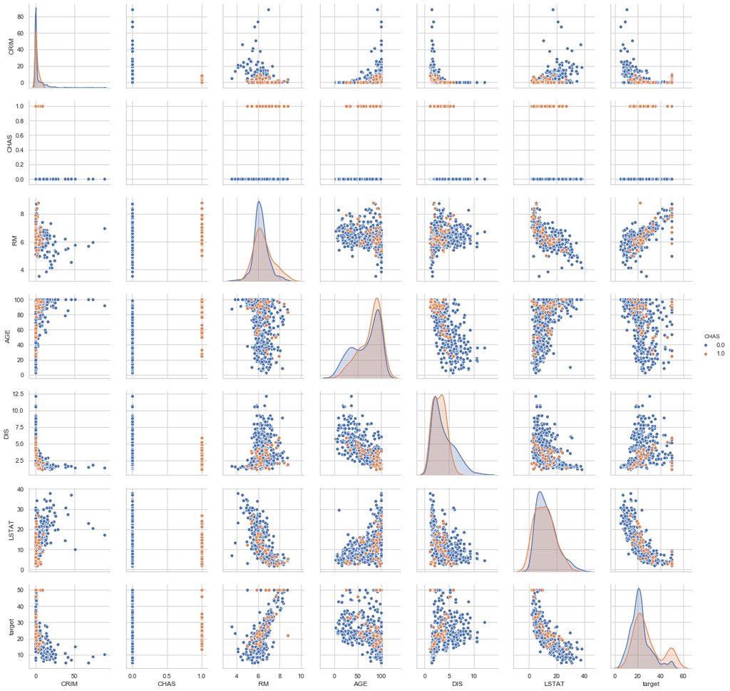

```python
sns.pairplot(data_tar[['CRIM', 'CHAS', 'RM', 'AGE', 'DIS', 'LSTAT','target']],hue='CHAS',diag_kind='kde',kind='scatter')
```

Из парного графика видно, что существует аппроксимация линейной зависимости между «target» и столбцом «RM». Существует также аппроксимация экспоненциальной связи между «target» и столбцом «LSTAT». Таким образом, мы можем нарисовать линию и посмотреть, сколько данных рядом с ней

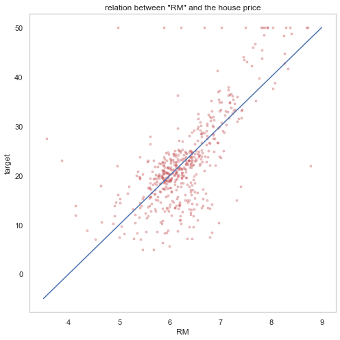

```python
fig=plt.figure(figsize=(8,8))
ax=fig.gca()
ax.grid()
plt.plot(data_tar['RM'],data_tar['target'],'.r',alpha=0.3)
ax.set_xlabel('RM')
ax.set_ylabel('target')
ax.set_title('relation between "RM" and the house price')
xxx=np.linspace(3.5,9)
yyy=10*xxx-40
plt.plot(xxx,yyy,'b')
```

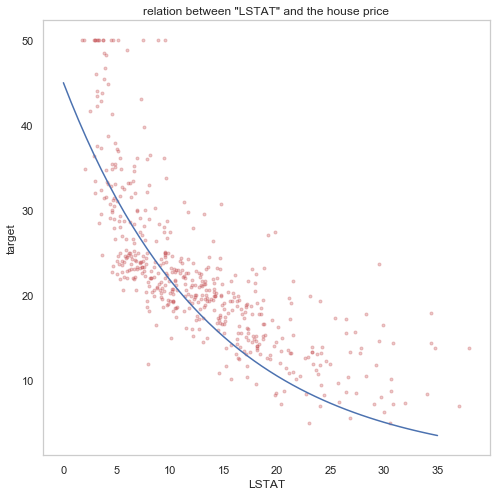

```python
fig=plt.figure(figsize=(8,8))
ax=fig.gca()
ax.grid()
plt.plot(data_tar['LSTAT'],data_tar['target'],'.r',alpha=0.3)
ax.set_xlabel('LSTAT')
ax.set_ylabel('target')
ax.set_title('relation between "LSTAT" and the house price')
xxx=np.linspace(0,35)
yyy=45*(0.93**(xxx))
plt.plot(xxx,yyy,'b')
```

## Histogram

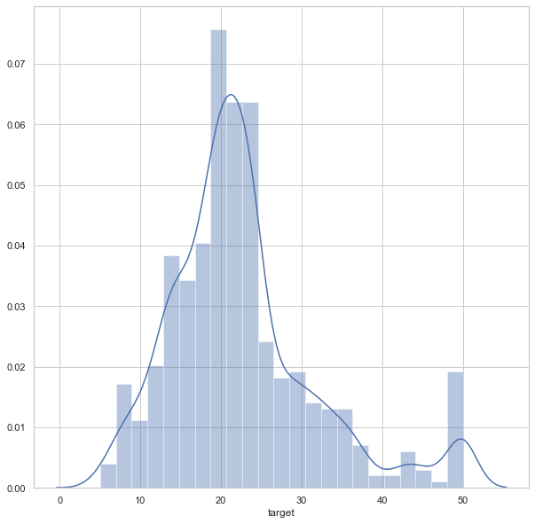

```python
fig, ax = plt.subplots(figsize=(10,10))
sns.distplot(data_tar['target'])
```

## Box Plot

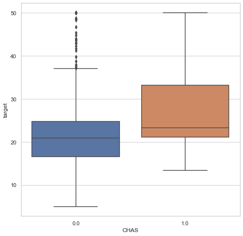

```python
fig=plt.figure(figsize=(8,8))
ax=fig.gca()
sns.boxplot(x='CHAS',y='target',data=data_tar,ax=ax)
```

Из коробочного графика мы видим, что средняя цена домов, ограничивающих реку, больше, чем тех, которые не связывают ее.

## Violin plot

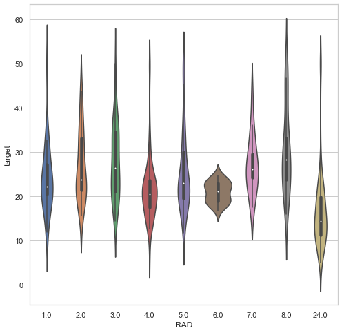

```python
fig=plt.figure(figsize=(8,8))
ax=fig.gca()
sns.violinplot(x='RAD',y='target',data=data_tar,ax=ax)
```

Из Violin Plot видно, что цены на дома, которые имеют большой радиус от шоссе, также низки, что логично.

## Информация о корреляции признаков

```python
corr_mat=data_tar.corr().round(2)
```

```python
corr_mat
```

|  | CRIM | ZN | INDUS | CHAS | NOX | RM | AGE | DIS | RAD | TAX | PTRATIO | B | LSTAT | target |
| --- | --- | --- | --- | --- | --- | --- | --- | --- | --- | --- | --- | --- | --- | --- |
| CRIM | 1.00 | -0.20 | 0.41 | -0.06 | 0.42 | -0.22 | 0.35 | -0.38 | 0.63 | 0.58 | 0.29 | -0.39 | 0.46 | -0.39 |
| ZN | -0.20 | 1.00 | -0.53 | -0.04 | -0.52 | 0.31 | -0.57 | 0.66 | -0.31 | -0.31 | -0.39 | 0.18 | -0.41 | 0.36 |
| INDUS | 0.41 | -0.53 | 1.00 | 0.06 | 0.76 | -0.39 | 0.64 | -0.71 | 0.60 | 0.72 | 0.38 | -0.36 | 0.60 | -0.48 |
| CHAS | -0.06 | -0.04 | 0.06 | 1.00 | 0.09 | 0.09 | 0.09 | -0.10 | -0.01 | -0.04 | -0.12 | 0.05 | -0.05 | 0.18 |
| NOX | 0.42 | -0.52 | 0.76 | 0.09 | 1.00 | -0.30 | 0.73 | -0.77 | 0.61 | 0.67 | 0.19 | -0.38 | 0.59 | -0.43 |
| RM | -0.22 | 0.31 | -0.39 | 0.09 | -0.30 | 1.00 | -0.24 | 0.21 | -0.21 | -0.29 | -0.36 | 0.13 | -0.61 | 0.70 |
| AGE | 0.35 | -0.57 | 0.64 | 0.09 | 0.73 | -0.24 | 1.00 | -0.75 | 0.46 | 0.51 | 0.26 | -0.27 | 0.60 | -0.38 |
| DIS | -0.38 | 0.66 | -0.71 | -0.10 | -0.77 | 0.21 | -0.75 | 1.00 | -0.49 | -0.53 | -0.23 | 0.29 | -0.50 | 0.25 |
| RAD | 0.63 | -0.31 | 0.60 | -0.01 | 0.61 | -0.21 | 0.46 | -0.49 | 1.00 | 0.91 | 0.46 | -0.44 | 0.49 | -0.38 |
| TAX | 0.58 | -0.31 | 0.72 | -0.04 | 0.67 | -0.29 | 0.51 | -0.53 | 0.91 | 1.00 | 0.46 | -0.44 | 0.54 | -0.47 |
| PTRATIO | 0.29 | -0.39 | 0.38 | -0.12 | 0.19 | -0.36 | 0.26 | -0.23 | 0.46 | 0.46 | 1.00 | -0.18 | 0.37 | -0.51 |
| B | -0.39 | 0.18 | -0.36 | 0.05 | -0.38 | 0.13 | -0.27 | 0.29 | -0.44 | -0.44 | -0.18 | 1.00 | -0.37 | 0.33 |
| LSTAT | 0.46 | -0.41 | 0.60 | -0.05 | 0.59 | -0.61 | 0.60 | -0.50 | 0.49 | 0.54 | 0.37 | -0.37 | 1.00 | -0.74 |
| target | -0.39 | 0.36 | -0.48 | 0.18 | -0.43 | 0.70 | -0.38 | 0.25 | -0.38 | -0.47 | -0.51 | 0.33 | -0.74 | 1.00 |

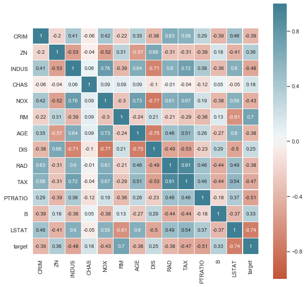

```python
fig, ax=plt.subplots(figsize=(10,10))
sns.heatmap(corr_mat,annot=True,annot_kws={"size": 10},vmin=-1, vmax=1, center=0,
    cmap=sns.diverging_palette(20, 220, n=200),linewidths = 0.1,square=True)
```

так что видно, что цель имеет хорошую корреляцию с переменными LSTAT и RM.  
Также существует высокая корреляция между двумя переменными TAX и RAD, что логично, поскольку дома, расположенные рядом с автомагистралями (центр города), будут облагаться более высокими налогами. Таким образом, мы можем выбрать только один из них, чтобы предсказать цены.  
Мы также видим, что существует хорошая корреляция между переменной DIS и {NOX, INDUS и AGE} значений {0,77, 0,71, 0,75}. Для этого мы можем отказаться от одного из этих вариантов, как это может быть обнаружено с помощью других.  
Наконец, мы видим, что, находится ли дом на реке или нет, имеет очень низкую корреляцию с ценой, таким образом, мы можем отказаться от этой переменной при построении сети.

## список литературы

1. sklearn.datasets.load_boston, [https://scikit-learn.org/stable/modules/generated/sklearn.datasets.load_boston.html]
2. The Python Graph Gallery, [https://python-graph-gallery.com/]
3. Introduction to Data Visualization in Python, [https://towardsdatascience.com/introduction-to-data-visualization-in-python-89a54c97fbed]
4. Violin plots explained, [https://towardsdatascience.com/violin-plots-explained-fb1d115e023d]